# Clase 7

# Tarea 7.

# Validación

- Estudiante: Brian Durán

Librerias

```r
library(caTools)
library(rpart)
library(dplyr)
library(visdat)
library(tidyr)
library(GGally)
library(rpart.plot)
library(randomForest)
library(neuralnet)
library(e1071)
library(ROCR)
#..........Librerias de los modelos
```

### Análisis del Problema

Construya el análisis del problema

Los datos se obtienen mediante el parte oficial de tránsito que realiza la Dirección General de Policía de Tránsito al presentarse un accidente, los cuales ingresan a la base de datos de dos formas (hand held y papel). Debido a que parte de la labor principal de la Institución es salvar vidas, y por los recursos limitados que existen, se trabaja solo con accidentes con heridos y/o fallecidos; y no se trabaja con accidentes que presentan solo daños materiales.

Fuente del dataset: http://datosabiertos.csv.go.cr/dashboards/19683/accidentes/

### Análisis exploratorio

Cargue el archivo en una variable

```r
personas_accidentadas_original <- read.csv("personas_accidentadas.csv", encoding = "UTF-8", na.strings = c("Desconocido", "Desconocida"), stringsAsFactors = TRUE)
```

Desarolle el entendimiento de los datos

```r
head(personas_accidentadas_original)
```

```
##   A_Persona           Rol  TipoLesion Edad Edad.quinquenal   Sexo  Año
## 1         1 Pasajero moto Herido leve   15      De 15 a 19  Mujer 2015
## 2         1  Motociclista      Muerte   47      De 45 a 49 Hombre 2015
## 3         1 Pasajero moto Herido leve   NA            <NA> Hombre 2013
## 4         1  Motociclista       Ileso   20      De 20 a 24 Hombre 2013
## 5         1 Pasajero moto Herido leve   NA            <NA> Hombre 2013
## 6         1 Pasajero moto Herido leve   28      De 25 a 29  Mujer 2013
##       Mes       Dia  Provincia    Canton    Distrito       Dia.1
## 1   Enero   Domingo Puntarenas Coto Brus    Sabalito   1.Domingo
## 2   Enero   Domingo Puntarenas Coto Brus    Sabalito   1.Domingo
## 3   Marzo   Domingo   San José  San José    Hospital   1.Domingo
## 4   Marzo   Domingo   San José  San José    Hospital   1.Domingo
## 5   Marzo   Domingo   San José  San José    Hospital   1.Domingo
## 6 Febrero Miércoles   San José  Puriscal San Antonio 4.Miércoles
##        Mes.1 Edad.quinquenal.1
## 1   A. Enero           15 A 19
## 2   A. Enero           45 A 49
## 3   C. Marzo              <NA>
## 4   C. Marzo           20 A 24
## 5   C. Marzo              <NA>
## 6 B. Febrero           25 A 29
```

Como se mencionó en el análisis del problema, los datos presentan información sobre accidentes de tránsito occurridos en distintos sectores del país.

Existen 15 carácterísticas en el conjunto de datos, las cuales son:

- A_Persona: parece ser un tipo de columna que se originó en alguna consulta, no parece ser relevante para el análisis.
- Rol: El rol de la persona en el accidente. Niveles: Pasajero moto, Motociclista, Conductor, Peatón, Dueño de propiedad, Pasajero carro, Ciclista, Pasajero bus o microbús, Pasajero bicicleta, Otro.
- TipoLesion: Herido grave, Herido leve, Ileso o Muerte.
- Edad: Edad de la persona involucrada en el accidente.
- Edad.quinquenal: Edad de la persona involucrada en el accidente en quinquenios (rango de 5 años), no parece ser muy relevante ya qe se cuenta con la edad especifica de dicha persona.
- Sexo: Hombre o Mujer
- Año: Año en el que ocurrió el accidente: 2013 2014 2015 2016 2017
- Mes: Mes en el que ocurrió el accidente
- Día: Día de la semana en el cual ocurrió el accidente
- Provincia: Provincia en la cual occurrió el accidente
- Cantón: Cantón en la cual occurrió el accidente
- Distrito: Distrito en la cual occurrió el accidente
- Día.1: tiene la misma información que la columna “Día” en un formato diferente, por ejemplo “1.Domingo” en lugar de “Domingo”
- Mes.1: tiene la misma información que la columna “Mes” en un formato diferente, por ejemplo “A. Enero” en lugar de “Enero”
- Edad.quinquenal.1: tiene la misma información que la columna “Edad quinquenal” en un formato diferente, por ejemplo “15 A 19” en lugar de “De 15 a 19”

Basándose en la descripción de variables anterior, se puede ver que la columna “A_Persona”, “Día.1”, “Mes.1” y “Edad.quinquenal.1” pueden ser removidas del dataframe, ya que no aportan un valor al análisis.

```r
personas_accidentadas <- personas_accidentadas_original %>%
  select(-c("A_Persona", "Edad.quinquenal", "Dia.1", "Mes.1", "Edad.quinquenal.1"))
head(personas_accidentadas)
```

```
##             Rol  TipoLesion Edad   Sexo  Año     Mes       Dia  Provincia
## 1 Pasajero moto Herido leve   15  Mujer 2015   Enero   Domingo Puntarenas
## 2  Motociclista      Muerte   47 Hombre 2015   Enero   Domingo Puntarenas
## 3 Pasajero moto Herido leve   NA Hombre 2013   Marzo   Domingo   San José
## 4  Motociclista       Ileso   20 Hombre 2013   Marzo   Domingo   San José
## 5 Pasajero moto Herido leve   NA Hombre 2013   Marzo   Domingo   San José
## 6 Pasajero moto Herido leve   28  Mujer 2013 Febrero Miércoles   San José
##      Canton    Distrito
## 1 Coto Brus    Sabalito
## 2 Coto Brus    Sabalito
## 3  San José    Hospital
## 4  San José    Hospital
## 5  San José    Hospital
## 6  Puriscal San Antonio
```

#### Análisis de valores faltantes

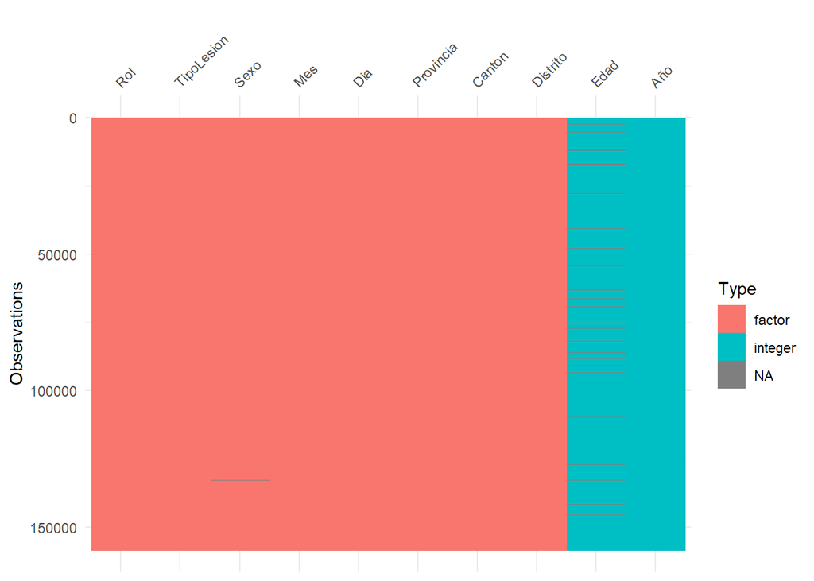

```r
vis_dat(personas_accidentadas, warn_large_data=FALSE)
```

Porcentanje de filas con datos nulos

```r
(sum(is.na(personas_accidentadas$Edad)) / nrow(personas_accidentadas)) * 100
```

```
## [1] 5.186901
```

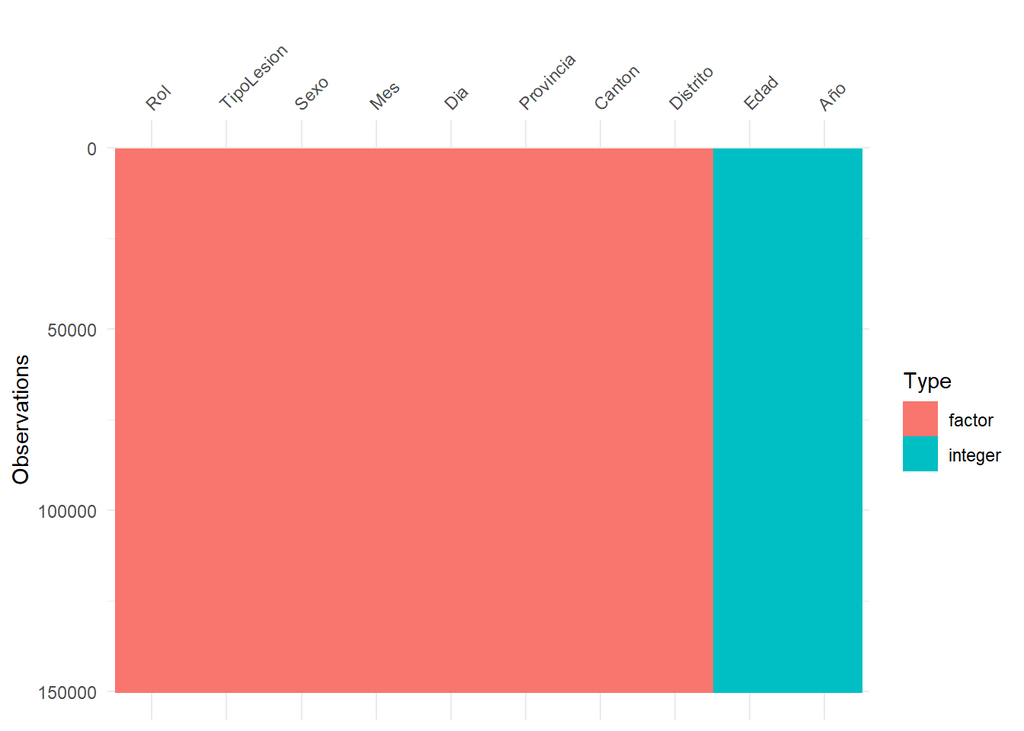

```r
personas_accidentadas <- personas_accidentadas %>%
  drop_na()
vis_dat(personas_accidentadas, warn_large_data=FALSE)
```

Para este conjunto de datos las clases que se van a tomar en cuenta serán si el individuo resultó **ileso** o nó después del accidente, por lo tanto para la columna *TipoLesion* cada aparición de la palabra **Ileso** se conservará tal y como está y el resto de valores (Herido leve, Herido grave y Muerte) se van a substituir por **No Ileso**.

```r
personas_accidentadas$TipoLesion <- as.character(personas_accidentadas$TipoLesion)
personas_accidentadas$TipoLesion[personas_accidentadas$TipoLesion %in% c("Herido leve", "Herido grave", "Muerte")] <- "No_ileso"
personas_accidentadas$TipoLesion <- factor(personas_accidentadas$TipoLesion)
```

#### Correlaciones entre las variables

Total de individuos por rol según el tipo de lesión

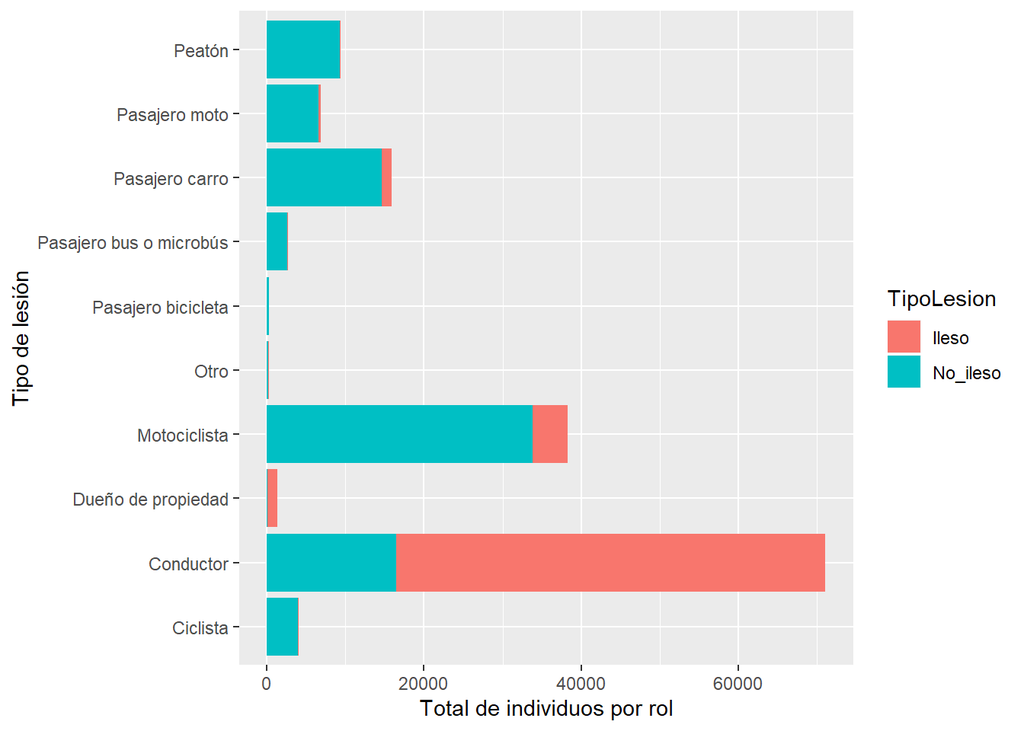

```r
accidentes_por_rol <- personas_accidentadas %>%
  group_by(Rol, TipoLesion) %>%
  summarize(total = n())

ggplot(accidentes_por_rol) +
  geom_bar(aes(x = Rol, weight = total, fill=TipoLesion)) +
  labs(x="Tipo de lesión", y="Total de individuos por rol") +
  coord_flip()
```

Total de individuos por provincia según el tipo de lesión

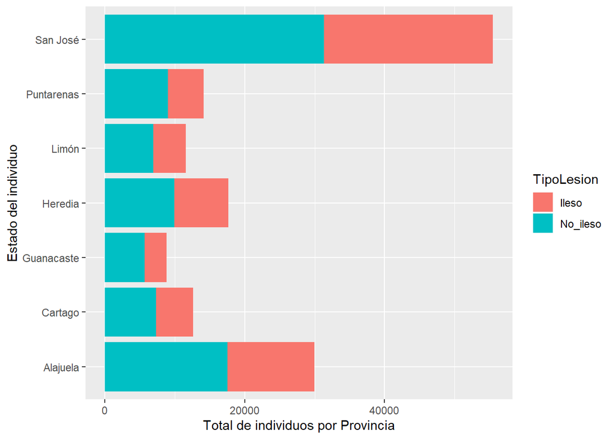

```r
accidentes_por_rol <- personas_accidentadas %>%
  group_by(Provincia, TipoLesion) %>%
  summarize(total = n())

ggplot(accidentes_por_rol) +
  geom_bar(aes(x = Provincia, weight = total, fill=TipoLesion)) +
  labs(x="Estado del individuo", y="Total de individuos por Provincia") +
  coord_flip()
```

### Modelado

Realice al menos 5 modelos de los observados en clase

Datos de entrenamiento y pruebas

```r
set.seed(1)
# Primero se crea un vector de valores lógicos basándose en el data.frame original
splt <- sample.split(personas_accidentadas$TipoLesion, SplitRatio = 0.7)
# Luego se utiliza el set creado anteriormente para dividir la información en un conjunto de datos de entrenamiento y prueba
datos_entrenamiento <- personas_accidentadas[splt,]
datos_prueba <- personas_accidentadas[!splt,]
```

#### Árboles de decisión

##### Creación del modelo

```r
modelo_arbol_decision <- rpart(TipoLesion ~ Rol, data = datos_entrenamiento, method =  'class')
```

##### Evaluación del modelo

Predicciones:

```r
predicciones_arbol_decision <- predict(modelo_arbol_decision, newdata = datos_prueba, type = 'class')
```

###### Matriz de confusión

```r
matriz_confusion_dt <- table(datos_prueba$TipoLesion, predicciones_arbol_decision)
matriz_confusion_dt
```

```
##           predicciones_arbol_decision
##            Ileso No_ileso
##   Ileso    16731     1986
##   No_ileso  4998    21340
```

**Métricas a partir de la matriz de confusión**

- *Exactitud Total* (observaciones clasificadas apropiadamente) = 84.49%. Hubieron 16731 *Ilesos* y 21340 *No Ilesos* clasificados correctamente, mientras que hubieron 4998 *No Ilesos* y 1986 *Ilesos* clasificados incorrectamente.

$$\begin{equation}Exactitud=\frac{VP+VN}{Total}\end{equation}$$

```r
print((matriz_confusion_dt[1,1] + matriz_confusion_dt[2,2]) / sum(matriz_confusion_dt) )
```

```
## [1] 0.8449895
```

- *Sensibilidad* (porcentaje de positivos verdaderos - de los individuos que realmente resultaron *Ilesos*, ¿cuántas clasificó apropiadamente el modelo?) = 89.38%. (De los 18717 individuos que resultaron *Ilesos*, 16731 fueron clasificados correctamente)

$$\begin{equation}\text{Sensibilidad}=\frac{VP}{\text{Total Positivos}}\end{equation}$$

```r
print(matriz_confusion_dt[1,1] / (matriz_confusion_dt[1,1] + matriz_confusion_dt[1,2]))
```

```
## [1] 0.8938933
```

$$\begin{equation}\text{Precisión}=\frac{VP}{\text{Total clasificados positivos}}\end{equation}$$

```r
print(matriz_confusion_dt[1,1] / (matriz_confusion_dt[1,1] + matriz_confusion_dt[2,1] ))
```

```
## [1] 0.7699848
```

- *Especificidad* (porcentaje de negativos verdaderos - en este caso, de los individuos que realmente resultaron *No Ilesos*, ¿cuántas clasificó apropiadamente el modelo?) = 81.02% (de las 26,338 *No Ilesos*, 21340 fueron correctamente clasificados).

$$\begin{equation}\text{Especificidad}=\frac{VN}{\text{Total Negativos}}\end{equation}$$

```r
print(matriz_confusion_dt[2,2] / (matriz_confusion_dt[2,1] + matriz_confusion_dt[2,2]))
```

```
## [1] 0.8102362
```

###### Curva ROC

```r
prediccionesROC = prediction(c(predicciones_arbol_decision), c(datos_prueba[,'TipoLesion']))
as.numeric(performance(prediccionesROC, "auc")@y.values)
```

```
## [1] 0.8520647
```

```r
plot(performance(prediccionesROC, "tpr", "fpr"),
colorize = T,
print.cutoffs.at = seq(0,1,by = 0.1),
text.adj = c(-0.2,1.7),
main = 'Curva ROC del modelo')
```

[output not shown]

#### Bosques aleatorios

##### Creación del modelo

```r
set.seed(1)
modelo_bosque_aleatorio <- randomForest(TipoLesion ~ Rol, data = datos_entrenamiento)
```

##### Evaluación del modelo

Predicciones:

```r
predicciones_bosque_aleatorio <- predict(modelo_bosque_aleatorio, newdata = datos_prueba, type = 'class')
```

###### Matriz de confusión

```r
matriz_confusion_rf <- table(datos_prueba$TipoLesion, predicciones_bosque_aleatorio)
matriz_confusion_rf
```

```
##           predicciones_bosque_aleatorio
##            Ileso No_ileso
##   Ileso    16731     1986
##   No_ileso  4998    21340
```

**Métricas a partir de la matriz de confusión**

- *Exactitud Total* (observaciones clasificadas apropiadamente) = 84.49%. Hubieron 16731 *Ilesos* y 21340 *No Ilesos* clasificados correctamente, mientras que hubieron 4998 *No Ilesos* y 1986 *Ilesos* clasificados incorrectamente.

$$\begin{equation}Exactitud=\frac{VP+VN}{Total}\end{equation}$$

```r
print((matriz_confusion_rf[1,1] + matriz_confusion_rf[2,2]) / sum(matriz_confusion_rf) )
```

```
## [1] 0.8449895
```

- *Sensibilidad* (porcentaje de positivos verdaderos - de los individuos que realmente resultaron *Ilesos*, ¿cuántas clasificó apropiadamente el modelo?) = 89.38%. (De los 18717 individuos que resultaron *Ilesos*, 16731 fueron clasificados correctamente)

$$\begin{equation}\text{Sensibilidad}=\frac{VP}{\text{Total Positivos}}\end{equation}$$

```r
print(matriz_confusion_rf[1,1] / (matriz_confusion_rf[1,1] + matriz_confusion_rf[1,2]))
```

```
## [1] 0.8938933
```

$$\begin{equation}\text{Precisión}=\frac{VP}{\text{Total clasificados positivos}}\end{equation}$$

```r
print(matriz_confusion_rf[1,1] / (matriz_confusion_rf[1,1] + matriz_confusion_rf[2,1] ))
```

```
## [1] 0.7699848
```

- *Especificidad* (porcentaje de negativos verdaderos - en este caso, de los individuos que realmente resultaron *No Ilesos*, ¿cuántas clasificó apropiadamente el modelo?) = 81.02% (de las 26,338 *No Ilesos*, 21340 fueron correctamente clasificados).

$$\begin{equation}\text{Especificidad}=\frac{VN}{\text{Total Negativos}}\end{equation}$$

```r
print(matriz_confusion_rf[2,2] / (matriz_confusion_rf[2,1] + matriz_confusion_rf[2,2]))
```

```
## [1] 0.8102362
```

###### Curva ROC

```r
prediccionesROC = prediction(c(predicciones_bosque_aleatorio), c(datos_prueba[,'TipoLesion']))
as.numeric(performance(prediccionesROC, "auc")@y.values)
```

```
## [1] 0.8520647
```

```r
plot(performance(prediccionesROC, "tpr", "fpr"),
colorize = T,
print.cutoffs.at = seq(0,1,by = 0.1),
text.adj = c(-0.2,1.7),
main = 'Curva ROC del modelo')
```

[output not shown]

#### Regresión Logística

##### Creación del modelo

```r
modelo_regresion_logistica <- glm(TipoLesion ~ Rol, data = datos_entrenamiento, family = binomial)
```

##### Evaluación del modelo

Predicciones:

```r
predicciones_regresion_logistica <- predict(modelo_regresion_logistica, newdata = datos_prueba, type = 'response')
```

###### Matriz de confusión

```r
matriz_confusion_lr <- table(datos_prueba$TipoLesion, predicciones_regresion_logistica >= 0.5)
matriz_confusion_lr
```

```
##
##            FALSE  TRUE
##   Ileso    16731  1986
##   No_ileso  4998 21340
```

**Métricas a partir de la matriz de confusión**

- *Exactitud Total* (observaciones clasificadas apropiadamente) = 84.49%. Hubieron 16731 *Ilesos* y 21340 *No Ilesos* clasificados correctamente, mientras que hubieron 4998 *No Ilesos* y 1986 *Ilesos* clasificados incorrectamente.

$$\begin{equation}Exactitud=\frac{VP+VN}{Total}\end{equation}$$

```r
print((matriz_confusion_lr[1,1] + matriz_confusion_lr[2,2]) / sum(matriz_confusion_lr) )
```

```
## [1] 0.8449895
```

- *Sensibilidad* (porcentaje de positivos verdaderos - de los individuos que realmente resultaron *Ilesos*, ¿cuántas clasificó apropiadamente el modelo?) = 89.38%. (De los 18717 individuos que resultaron *Ilesos*, 16731 fueron clasificados correctamente)

$$\begin{equation}\text{Sensibilidad}=\frac{VP}{\text{Total Positivos}}\end{equation}$$

```r
print(matriz_confusion_lr[1,1] / (matriz_confusion_lr[1,1] + matriz_confusion_lr[1,2]))
```

```
## [1] 0.8938933
```

$$\begin{equation}\text{Precisión}=\frac{VP}{\text{Total clasificados positivos}}\end{equation}$$

```r
print(matriz_confusion_lr[1,1] / (matriz_confusion_lr[1,1] + matriz_confusion_lr[2,1] ))
```

```
## [1] 0.7699848
```

- *Especificidad* (porcentaje de negativos verdaderos - en este caso, de los individuos que realmente resultaron *No Ilesos*, ¿cuántas clasificó apropiadamente el modelo?) = 81.02% (de las 26,338 *No Ilesos*, 21340 fueron correctamente clasificados).

$$\begin{equation}\text{Especificidad}=\frac{VN}{\text{Total Negativos}}\end{equation}$$

```r
print(matriz_confusion_lr[2,2] / (matriz_confusion_lr[2,1] + matriz_confusion_lr[2,2]))
```

```
## [1] 0.8102362
```

###### Curva ROC

```r
prediccionesROC = prediction(c(predicciones_regresion_logistica), c(datos_prueba[,'TipoLesion']))
as.numeric(performance(prediccionesROC, "auc")@y.values)
```

```
## [1] 0.8660266
```

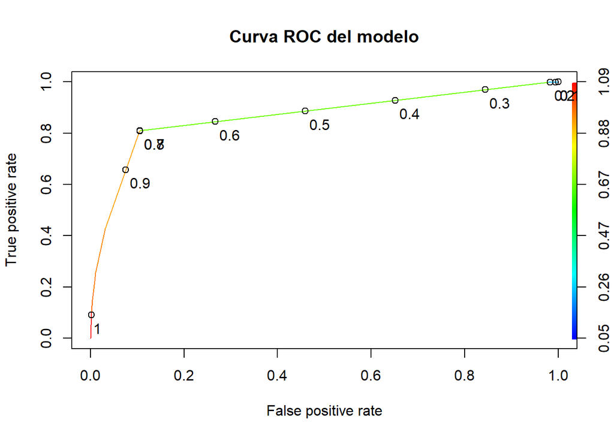

```r
plot(performance(prediccionesROC, "tpr", "fpr"),
colorize = T,
print.cutoffs.at = seq(0,1,by = 0.1),
text.adj = c(-0.2,1.7),
main = 'Curva ROC del modelo')
```

#### SVM

##### Creación del modelo

```r
modelo_svm <- svm(TipoLesion ~ Rol, data = datos_entrenamiento, kernel='linear',cross=2, scale=FALSE)
```

##### Evaluación del modelo

Predicciones:

```r
prediccion_svm <- predict(modelo_svm , newdata = datos_prueba)
```

###### Matriz de confusión

```r
matriz_confusion_svm <- table(datos_prueba$TipoLesion, prediccion_svm)
matriz_confusion_svm
```

```
##           prediccion_svm
##            Ileso No_ileso
##   Ileso    16731     1986
##   No_ileso  4998    21340
```

**Métricas a partir de la matriz de confusión**

- *Exactitud Total* (observaciones clasificadas apropiadamente) = 84.49%. Hubieron 16731 *Ilesos* y 21340 *No Ilesos* clasificados correctamente, mientras que hubieron 4998 *No Ilesos* y 1986 *Ilesos* clasificados incorrectamente.

$$\begin{equation}Exactitud=\frac{VP+VN}{Total}\end{equation}$$

```r
print((matriz_confusion_svm[1,1] + matriz_confusion_svm[2,2]) / sum(matriz_confusion_svm) )
```

```
## [1] 0.8449895
```

- *Sensibilidad* (porcentaje de positivos verdaderos - de los individuos que realmente resultaron *Ilesos*, ¿cuántas clasificó apropiadamente el modelo?) = 89.38%. (De los 18717 individuos que resultaron *Ilesos*, 16731 fueron clasificados correctamente)

$$\begin{equation}\text{Sensibilidad}=\frac{VP}{\text{Total Positivos}}\end{equation}$$

```r
print(matriz_confusion_svm[1,1] / (matriz_confusion_svm[1,1] + matriz_confusion_svm[1,2]))
```

```
## [1] 0.8938933
```

$$\begin{equation}\text{Precisión}=\frac{VP}{\text{Total clasificados positivos}}\end{equation}$$

```r
print(matriz_confusion_svm[1,1] / (matriz_confusion_svm[1,1] + matriz_confusion_svm[2,1] ))
```

```
## [1] 0.7699848
```

- *Especificidad* (porcentaje de negativos verdaderos - en este caso, de los individuos que realmente resultaron *No Ilesos*, ¿cuántas clasificó apropiadamente el modelo?) = 81.02% (de las 26,338 *No Ilesos*, 21340 fueron correctamente clasificados).

$$\begin{equation}\text{Especificidad}=\frac{VN}{\text{Total Negativos}}\end{equation}$$

```r
print(matriz_confusion_svm[2,2] / (matriz_confusion_svm[2,1] + matriz_confusion_svm[2,2]))
```

```
## [1] 0.8102362
```

###### Curva ROC

```r
prediccionesROC = prediction(c(prediccion_svm), c(datos_prueba[,'TipoLesion']))
as.numeric(performance(prediccionesROC, "auc")@y.values)
```

```
## [1] 0.8520647
```

```r
plot(performance(prediccionesROC, "tpr", "fpr"),
colorize = T,
print.cutoffs.at = seq(0,1,by = 0.1),
text.adj = c(-0.2,1.7),
main = 'Curva ROC del modelo')
```

[output not shown]

#### Redes Neuronales

##### Creación del modelo

```r
m <- model.matrix(
  ~TipoLesion + Rol,
  data = datos_entrenamiento
)

modelo_red_neuronal <- neuralnet(TipoLesionNo_ileso ~ RolConductor + RolMotociclista, data = m, hidden=4, rep=1, linear.output=T, stepmax=1e6)
```

##### Evaluación del modelo

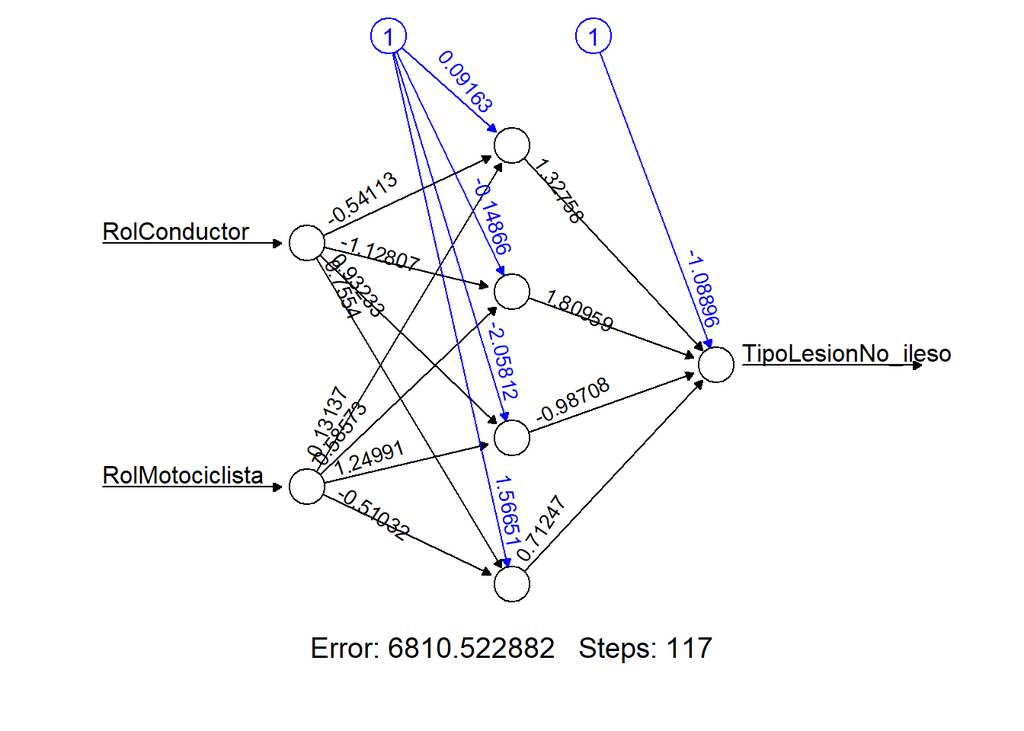

```r
plot(modelo_red_neuronal,rep="best")
```

Predicciones:

```r
mp <- model.matrix(
  ~TipoLesion + Rol,
  data = datos_prueba
)

predicciones_red_neuronal <- neuralnet::compute(modelo_red_neuronal,mp[,c("RolConductor","RolMotociclista")])

results <- data.frame(actual = mp, prediction = predicciones_red_neuronal$net.result)
head(results)
```

[output not shown]

[output cut: 20 more lines]

###### Evaluación

```r
results <- data.frame(actual = datos_prueba$TipoLesion, prediction = predicciones_red_neuronal$net.result)
head(results)
```

```
##      actual prediction
## 7  No_ileso  0.8854087
## 9     Ileso  0.2298359
## 10 No_ileso  0.9205241
## 11    Ileso  0.2298359
## 13 No_ileso  0.2298359
## 24    Ileso  0.2298359
```